# Curation of CP and MN motifs

Melanie Weilert (1028-02098-001-001)

January 07, 2022

# Introduction

The goal of this analysis is to curate motifs found by the TF-MoDISco run such that there are no redundancies due palindromes, sequence similarity, overlapping peak regions etc. After this, we will begin to analyze, perturb, and interpret the motifs.

# Computational Setup

```r
#Standard packages
library(rtracklayer) ; library(GenomicRanges); library(magrittr) ; library(Biostrings)
library(ggplot2) ; library(reshape2); library(plyranges); library(Rsamtools)
library(dplyr); library(data.table); library(patchwork); library(readr); library(testit)

#KNITR Options
setwd("/n/projects/mw2098/publications/2022_maven_ISL1/analysis/")
options(knitr.figure_dir="../figures/3_motif_curation", java.parameters = "- Xmx6g")

#Lab sources
source("../scripts/granges_common.r")
source("../scripts/metapeak_common.r")
source("../scripts/knitr_common.r")
source("../scripts/caching.r")
source("../scripts/metapeak_functions.R")

#Specific sources
library(BSgenome.Hsapiens.UCSC.hg19)
library(ggpubr)
source("../scripts/motif_functions.r")

#Pre-existing variables
model_prefix<-'seq_width1000-lr0.001-lambda100-n_dil_layers9-conv_kernel_size7-tconv_kernel_size7-filters64'
modisco_dir <- 'modisco/seq_width1000-lr0.001-lambda100-n_dil_layers9-conv_kernel_size7-tconv_kernel_size7-filters64/'
tasks <- c('I_WT_D6CM','I_WT_S3MN')
cp_peak_path <- '../bed/I_wt_d6cm_consensus_filtered.bed'
threads <- 5
dir.create('tsv/mapped_motifs/', recursive = T)
dir.create('bed/mapped_motifs/', recursive = T)
```

# Summary of motifs of interest

A summary of the TF-MoDISco runs on profile are below:

```r
motifs_of_interest.df <- data.frame(
  name = c('NKX2.5', 'GATA', 'ISL1',
           'LHX', 'LHX-ISL1-28', 'LHX-ISL1-10', 'LHX-ISL1-9',
           'NeuroD', 'EBF1', 'Onecut2', 'NKX2.5-alt'),
  task = c('I_WT_D6CM', 'I_WT_D6CM', 'I_WT_D6CM',
           'I_WT_S3MN', 'I_WT_S3MN', 'I_WT_S3MN', 'I_WT_S3MN',
           'I_WT_S3MN', 'I_WT_S3MN', 'I_WT_S3MN', 'I_WT_S3MN'),
  pattern = c(0, 1, 3,
              0, 3, 6, 7,
              1, 2, 4, 5)
)
motifs_of_interest.df
```

```
##           name      task pattern
## 1       NKX2.5 I_WT_D6CM       0
## 2         GATA I_WT_D6CM       1
## 3         ISL1 I_WT_D6CM       3
## 4          LHX I_WT_S3MN       0
## 5  LHX-ISL1-28 I_WT_S3MN       3
## 6  LHX-ISL1-10 I_WT_S3MN       6
## 7   LHX-ISL1-9 I_WT_S3MN       7
## 8       NeuroD I_WT_S3MN       1
## 9         EBF1 I_WT_S3MN       2
## 10     Onecut2 I_WT_S3MN       4
## 11  NKX2.5-alt I_WT_S3MN       5
```

# Collect motif instances

```r
cmds.vec<-lapply(1:nrow(motifs_of_interest.df), function(x){
  info.df<-motifs_of_interest.df[x,]
  cmd<-paste0('bpnet cwm-scan --contrib-file preds/', model_prefix,
              '/contrib.h5 --patterns metacluster_0/pattern_',
              info.df$pattern, ' ',
              modisco_dir, '/', info.df$task,
              '_profile tsv/mapped_motifs/',
              info.df$name, '_instances_noncurated_0based.tsv.gz')
  return(cmd)
}) %>% unlist
cmds.vec<-c('#!bin/bash', cmds.vec, '')

readr::write_lines(cmds.vec, file = '../tmp/cwm_scan_indiv_instances.sh', sep = '\n')
```

Run CWM-scanning to allocate.

```bash
bash /n/projects/mw2098/collaboration/for_srivastava/tmp/cwm_scan_indiv_instances.sh
```

Next import motifs.

```r
motifs.df<-lapply(1:nrow(motifs_of_interest.df), function(x){
  info.df<-motifs_of_interest.df[x,]
  df<-readr::read_tsv(paste0('tsv/mapped_motifs/', info.df$name, '_instances_noncurated_0based.tsv.gz')) %>%
    dplyr::mutate(pattern_name = info.df$name,
                  modisco_task = info.df$task)
}) %>% rbindlist(fill = TRUE)
```

Report number of motifs.

```r
table(motifs.df$pattern_name, motifs.df$example_interval_from_task)
```

```
##
##               I_WT_D6CM I_WT_S3MN
##   EBF1              342      2097
##   GATA             4176      1182
##   ISL1             2033      1012
##   LHX               575      4420
##   LHX-ISL1-10       284      1962
##   LHX-ISL1-28      4126     27601
##   LHX-ISL1-9        304      2205
##   NeuroD           1322      6386
##   NKX2.5           3184      1541
##   NKX2.5-alt        386      1496
##   Onecut2           431      6411
```

# Remove redundant palindromic mappings

Motifs that are palindromic will be mapped on the positive and negative strand with almost identical ranges. Here, we will remove redundantly mapped motifs and select the unique motif maps that have the highest importance score.

```r
#Remove palindromic motifs for each pattern.
motifs.gr<-lapply(motifs.df$pattern_name %>% unique, function(x){
  message(x)
  gr<-remove_palindromic_motifs_from_bpnet_instances(dfi = motifs.df, motif = x)
}) %>% GRangesList %>% unlist
```

# Remove redundantly mapped motifs due to overlapping peaks

When training with BPNet, peaks are found for each TF. If a genomic region has more than one peak, that region sequence is trained/mapped twice. This results in overreporting of motifs and redundancies in motif mapping. To filter these, we will resolve motifs by coordinate, strand, name, and select the motif that has the highest `contrib_weighted` score.

```r
motifs_unique.gr <- motifs.gr %>%
  as.data.frame %>%
  #creating a proxy group_by due to bugs with dplyr's grouping at high values.
  dplyr::mutate(coord_id = paste(seqnames, start, end, strand, pattern_name, sep = '-')) %>%
  dplyr::group_by(coord_id) %>%
  dplyr::slice_max(order_by = contrib_weighted, n = 1) %>%
  dplyr::ungroup() %>%
  dplyr::mutate(example_idx_deprecated = example_idx,
                motif_unique_id = 1:nrow(.)) %>% #Mark an temporary identifier for subsequent filtering
  dplyr::select(-example_idx, -coord_id) %>% #Remove because it cannot be grouped by example_idx
  GenomicRanges::makeGRangesFromDataFrame(df = ., keep.extra.columns = T, starts.in.df.are.0based = F)

assert("Filtering by peak redundancy did not work.", ((motifs_unique.gr %>% granges %>% unique %>% length) == (motifs_unique.gr  %>% length)))
```

# Measure %age of motifs across enhancer edges

```r
edge_motifs.df<-motifs_unique.gr %>% plyranges::filter(pattern_center <=100 | pattern_center>=900) %>% .$pattern_name %>% table %>% as.data.frame
total_motifs.df<-motifs_unique.gr$pattern_name %>% table %>% as.data.frame
total_motifs.df %>%
  dplyr::left_join(., edge_motifs.df, by = '.') %>%
  dplyr::rename(total_motif_count = Freq.x,edge_motif_count = Freq.y) %>%
  dplyr::mutate(perc_on_edge = round(edge_motif_count/total_motif_count, 2))
```

```
##              . total_motif_count edge_motif_count perc_on_edge
## 1         EBF1              2347                9            0
## 2         GATA              5195               10            0
## 3         ISL1              2927               10            0
## 4          LHX              4836                4            0
## 5  LHX-ISL1-10              2076                1            0
## 6  LHX-ISL1-28             16781               22            0
## 7   LHX-ISL1-9              2196                2            0
## 8       NeuroD              4015                5            0
## 9       NKX2.5              4538               22            0
## 10  NKX2.5-alt              1829                2            0
## 11     Onecut2              6725               25            0
```

```r
motifs_unique.gr<-motifs_unique.gr %>% plyranges::filter(!(pattern_center <=100 | pattern_center>=900))
```

Less than 1% of all motifs are on mapped BPNet window edges. However, we will filter out these motifs because of downstream perturbation predictions.

# Resolve/mark overlap of similar motifs

Many of the mapped motifs contain similarities such that they will map over the same sets of coordinate regions. To resolve these, we need to approach each comparison with a hierarchical, individualized regimen. Below, the steps will be listed for each group.

## Check for motif overlaps

Ensure that there isn’t an overrepresentation of unexpected overlapping motif pairs. We expect some overlaps, but checking to make sure that our curations are consistent. Here, we will filter out the longer motifs because we know that those overlaps will be highly represented.

```r
overlapping_motifs.gr<- motifs_unique.gr %>%
  GenomicRanges::reduce(ignore.strand = T) %>%
  plyranges::mutate(motif_island_id = 1:length(.))
overlapping_motifs.ov<-findOverlaps(motifs_unique.gr, overlapping_motifs.gr, ignore.strand = T)
assert('IDs do not allow indexing shortcut.', 1:length(motifs_unique.gr)==overlapping_motifs.ov@from)
motifs_unique.gr$motif_island_id<-overlapping_motifs.ov@to

#Group motifs by their island ID and display frequency of motif contents
grouped_motif_content.df<-motifs_unique.gr %>% as.data.frame %>%
  dplyr::group_by(motif_island_id) %>%
  dplyr::summarize(motif_content = paste0(sort(pattern_name), collapse = '_'))

grouped_motif_content.df$motif_content %>% table() %>% sort(decreasing = T) %>% head(n=15)
```

```
## .
##             LHX-ISL1-28                 Onecut2                    GATA
##                    6883                    3750                    3365
##                  NeuroD         LHX_LHX-ISL1-28                    EBF1
##                    3196                    1900                    1854
##     LHX-ISL1-28_Onecut2                  NKX2.5                     LHX
##                    1815                    1566                    1049
##             ISL1_NKX2.5  LHX-ISL1-28_LHX-ISL1-9        GATA_ISL1_NKX2.5
##                     673                     624                     546
## LHX-ISL1-10_LHX-ISL1-28      LHX-ISL1-28_NeuroD                    ISL1
##                     478                     422                     371
```

Because there are so many overlaps, we will mark which ISL1 motifs are overlapped with another motif, but we will not “filter” or “mark” these identities otherwise. When performing motif pair synergy analysis, these motifs will be automatically filtered out in both genomic and in silico testing.

## Description of motif overlap strategy

Here, as we are not sure of the role that competitive motif sites play in our system, we do not want to filter out motifs that overlap as they may be regions of interest. Instead, we will demarcate genomic regions that have sufficient overlaps based on each individual situation that we anticipate to be of interest. This will allow filtering strategies to be applied in the future such that each individual analysis can be tailored to specific questions about affinity, competition, and representative motif behaviors.

# Mark overlaps

Mark the coordinates for all the ISL1 partners in a column for later storage.

```r
testit::assert(motifs_unique.gr$motif_unique_id %>% unique %>% length == motifs_unique.gr %>% length)

#Mark all overlaps and corresponding coordinates
ov_with_itself.df<-findOverlaps(motifs_unique.gr, motifs_unique.gr, ignore.strand = T) %>%
  as.data.frame %>%
  dplyr::filter(queryHits != subjectHits) %>%
  dplyr::mutate(subjectChrom = seqnames(motifs_unique.gr) %>% as.character %>% .[subjectHits],
                subjectStart = start(motifs_unique.gr)[subjectHits],
                subjectEnd = end(motifs_unique.gr)[subjectHits],
                subjectName = motifs_unique.gr$pattern_name[subjectHits],
                subjectCoords = paste0(subjectChrom, ':', subjectStart, '-', subjectEnd, '_', subjectName))

#Merge to 'query-based' for many subject hits
query_with_itself.df<-ov_with_itself.df %>%
  dplyr::group_by(queryHits) %>%
  dplyr::summarize(subjectCoordsAll=paste0(sort(subjectCoords), collapse = '/')) %>%
  dplyr::arrange(queryHits)

#Mark overlaps as a separate column.
motifs_unique.gr$overlap_information<-NA
motifs_unique.gr$overlap_information[query_with_itself.df$queryHits] <- query_with_itself.df$subjectCoordsAll
```

# Finish formatting motifs

```r
motifs_curated.gr<-motifs_unique.gr %>%
  plyranges::select(-motif_unique_id) %>%
  plyranges::mutate(motif_id = 1:length(.))
```

Plot a general summary of the motifs.

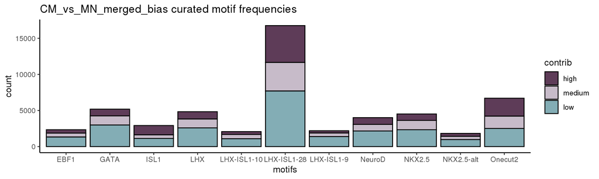

```r
ggplot(motifs_curated.gr %>% as.data.frame, aes(x = pattern_name))+
  geom_bar(aes(fill = factor(contrib_weighted_cat, levels = c('high','medium','low'))), color = 'black')+
  scale_fill_manual(values = rev(c('#83adb5', '#c7bbc9', '#5e3c58')), name = 'contrib')+
  scale_x_discrete(name = 'motifs')+
  ggtitle('CM_vs_MN_merged_bias curated motif frequencies')+
  theme_classic()
```

# Annotate motifs by their collected regional grouping

Because we took motifs based on their relative contribution and not the featured `example_idx` column, we need a new grouping annotation to define the motifs when we are conducting perturbations and other grouping systems. We will call this index `region_id`.

```r
islands.gr<-resize(motifs_curated.gr, 200, 'center') %>%
  GenomicRanges::reduce(ignore.strand = T) %>%
  plyranges::mutate(region_id = 0:(length(.)-1)) # Make region_id 0-based in order to be compatible with BPNet indexing properties.
ov<-findOverlaps(motifs_curated.gr, islands.gr, ignore.strand = T)
testit::assert((ov@from %>% unique %>% length) ==( ov@from %>% length))

#Show hoy many motifs there are per window
width(islands.gr) %>% summary
```

```
##    Min. 1st Qu.  Median    Mean 3rd Qu.    Max.
##   200.0   216.0   272.0   282.8   328.0   657.0
```

```r
ov@to %>% table %>% table
```

```
## .
##    1    2    3    4    5    6    7    8    9   10   11   12   13   14   15   16
## 2447 2908 3105 2634 1974 1090  609  272  135   69   24    8    4    3    1    1
```

```r
#Assign region_id to these motifs
motifs_curated.gr$region_id<-islands.gr$region_id[ov@to]
motifs_curated.gr$region_start_1based<-islands.gr[ov@to] %>% resize(., 1000, 'center') %>% start()
motifs_curated.gr$region_end_1based<-islands.gr[ov@to] %>% resize(., 1000, 'center') %>% end()

#Assert that all motifs are incorporated.
testit::assert('All motifs have a correct region', all(overlapsAny(motifs_curated.gr, resize(islands.gr, 1000, 'center'))))

#Export regions in 0-based coordinates
islands.gr<-islands.gr %>% resize(., 1000, 'center')
rtracklayer::export(islands.gr %>% plyranges::mutate(name = region_id), 'bed/mapped_motifs/all_grouped_regions_0based.bed', format = 'BED')
```

# Export curated motifs

```r
motifs_curated.df<-motifs_curated.gr %>% as.data.frame()
readr::write_tsv(motifs_curated.df, 'tsv/mapped_motifs/all_instances_curated_1based.tsv.gz')
rtracklayer::export(motifs_curated.gr %>% plyranges::mutate(name = paste0(pattern_name, '_', motif_id, '_', region_id)),
                    'bed/mapped_motifs/all_instances_curated_0based.bed', format = 'BED')
print(length(motifs_curated.gr))
```

```
## [1] 53353
```

In conclusion, motifs were curated based on redundancies and saved to 1-based and 0-based coordinates. These will be the reference motifs that we base subsequent analysis on.

# Define motifs that overlap with CPs.

```r
motif_ids_overlapping_cps<-subsetByOverlaps(motifs_curated.gr,
                                            rtracklayer::import(cp_peak_path) %>% resize(1000, 'center'),
                                            ignore.strand = T)$motif_id
write(motif_ids_overlapping_cps, 'tsv/motif_ids_overlapping_cps.txt')
```